# Project 1- Applied statistics (abhinandan)

## Start of Project 1 - Applied Statistics

```python
import numpy as np
import pandas as pd
import matplotlib.pyplot as plt
import seaborn as sns
import scipy.stats as stats
%matplotlib inline
sns.set(color_codes=True)
```

## Module 1 : Question Based

Solution:

i. Planned to purchase and actually place order = 400 Total people in survey = 2000

- Probablity = (people planned and actualy purchase) = 400/2000 = 0.2

ii. To find: P(People planned to purchase AND Placed order | People planned to purchase)

- P1(People planned and Purchase) = 400/2000 = 0.2
- P2(Planned to purchase) = 500/2000
- P(result) = P1/P2 = (400/2000)/(500/2000) = 0.8

### Question 2:

An electrical manufacturing company conducts quality checks at specified periods on the products it manufactures. Historically, the failure rate for the manufactured item is 5%. Suppose a random sample of 10 manufactured items is selected. Answer the following questions.  
A. Probability that none of the items are defective?  
B. Probability that exactly one of the items is defective?  
C. Probability that two or fewer of the items are defective?  
D. Probability that three or more of the items are defective ?

Solution:

To solve this problem, we'll use Binomial distribution. here,sample n = 10  
p = 0.05 or 5% k = array of 10 set (from 0 to 11)

```python
n=10
p=0.05
k=np.arange(0,11)
print(n,p,k)
```

```
10 0.05 [ 0  1  2  3  4  5  6  7  8  9 10]
```

```python
binomial = stats.binom.pmf(k,n,p)
binomial
```

```
array([5.98736939e-01, 3.15124705e-01, 7.46347985e-02, 1.04750594e-02,
       9.64808106e-04, 6.09352488e-05, 2.67259863e-06, 8.03789063e-08,
       1.58642578e-09, 1.85546875e-11, 9.76562500e-14])
```

```python
# sol A:
print('A. Probablity that --NO item is defective--',binomial[0])
```

```
A. Probablity that --NO item is defective-- 0.5987369392383789
```

```python
#sol B:
print('B. Probablity that --only one item is defective--',binomial[1])
```

```
B. Probablity that --only one item is defective-- 0.31512470486230504
```

```python
#sol C: can also be done with cumm. function
print('C. Probablity that --2 or fewer are defective--',
          (binomial[0]+binomial[1]+binomial[2]))
```

```
C. Probablity that --2 or fewer are defective-- 0.9884964426207035
```

```python
cumm_binomial = stats.binom.cdf(k,n,p)
print(cumm_binomial)
```

```
[0.59873694 0.91386164 0.98849644 0.9989715  0.99993631 0.99999725
 0.99999992 1.         1.         1.         1.        ]
```

```python
#sol D:
print('D. Probablity that --3 or more are defective--',1-cumm_binomial[2])
```

```
D. Probablity that --3 or more are defective-- 0.01150355737929687
```

### Question 3:

A car salesman sells on an average 3 cars per week.  
A. Probability that in a given week he will sell some cars.  
B. Probability that in a given week he will sell 2 or more but less than 5 cars.  
C. Plot the poisson distribution function for cumulative probability of cars sold per-week vs number of cars sold perweek.

Solutiom:

to solve this problem, we'll use Poisson's theorm rule. here, Lambda(rate) = 3 sample n = 17

```python
rate = 3
n = np.arange(0,18)
poission = stats.poisson.cdf(n,rate)
poission
```

```
array([0.04978707, 0.19914827, 0.42319008, 0.64723189, 0.81526324,
       0.91608206, 0.96649146, 0.9880955 , 0.99619701, 0.99889751,
       0.99970766, 0.99992861, 0.99998385, 0.9999966 , 0.99999933,
       0.99999988, 0.99999998, 1.        ])
```

```python
#sol A:
print('A. Probablity that --sell some cars in a week--',1-poission[0])
```

```
A. Probablity that --sell some cars in a week-- 0.950212931632136
```

```python
#sol: B
print('B. Probablity that --sell 2 or more but less than 5 cars--',poission[4]-poission[1])
```

```
B. Probablity that --sell 2 or more but less than 5 cars-- 0.6161149710523164
```

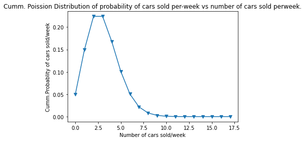

```python
#sol C:
p = stats.poisson.pmf(n,rate)
plt.plot(n,p,'-v')
plt.xlabel('Number of cars sold/week')
plt.ylabel('Cumm.Probablity of cars sold/week')
plt.title('Cumm. Poission Distribution of probability of cars sold per-week vs number of cars sold perweek.')
plt.show()
```

### Question 4:

Question: Accuracy in understanding orders for a speech based bot at a restaurant is important for the Company X which has designed, marketed and launched the product for a contactless delivery due to the COVID-19 pandemic. Recognition accuracy that measures the percentage of orders that are taken correctly is 86.8%. Suppose that you place order with the bot and two friends of yours independently place orders with the same bot. Answer the following questions.  
A. What is the probability that all three orders will be recognised correctly?  
B. What is the probability that none of the three orders will be recognised correctly?  
C. What is the probability that at least two of the three orders will be recognised correctly?

Solution:

To solve this problem, we'll use binomial function  
here, p = 0.868 or 86.8%  
n = 3

```python
k = np.arange(0,4)
n=3
p=0.868
binomial1 = stats.binom.pmf(k,n,p)
binomial1
```

```
array([0.00229997, 0.0453721 , 0.2983559 , 0.65397203])
```

```python
#sol A: all 3 orders correct
print('A. Probablity that -- all 3 orders are correct-- is', binomial1[3])
```

```
A. Probablity that -- all 3 orders are correct-- is 0.653972032
```

```python
#sol B: no correct orders were recognized
print('B. Probablity that --no orders were recognized-- is', binomial1[0])
```

```
B. Probablity that --no orders were recognized-- is 0.002299968
```

```python
#Sol C: atleast 2 out of 3 orders were selected ---> P[2] + P[3]
print("C. Probablity that -- aleast 2 of 3 were recog.--",(binomial1[2]+binomial1[3]).round(3))
```

```
C. Probablity that -- aleast 2 of 3 were recog.-- 0.952
```

### Question 5:

A group of 300 professionals sat for a competitive exam. The results show the information of marks obtained by them have a mean of 60 and a standard deviation of 12. The pattern of marks follows a normal distribution. Answer the following questions.  
A. What is the percentage of students who score more than 80.  
B. What is the percentage of students who score less than 50.  
C. What should be the distinction mark if the highest 10% of students are to be awarded distinction?

Solution:

we will solve this question through the help of z-test. test stat z = value - mean / SD

```python
a=stats.norm.cdf(80,loc=60,scale=12)
print('% of Students scored less than 80=',a)

#sol A:
print('\n A. Percentage of students who score more than 80 =',(1-a)*100,'%')
```

```
% of Students scored less than 80= 0.9522096477271853

 A. Percentage of students who score more than 80 = 4.77903522728147 %
```

```python
# Sol B:
b=stats.norm.cdf(50,60,12)
print('B. percentage of students who score less than 50 = ', b*100,'%')
```

```
B. percentage of students who score less than 50 =  20.232838096364308 %
```

# sol C:

We will have to use the Standard Normal Distribution table in reverse to solve this problem .  
We know that we have to find the top 10% of the class. i.e.  
P(z=(x-60)/12))=0.1

Now, we know that top 10% means 0.9. hence, we search for 0.9(or close) value in table.  
In table 0.8997 is present. So, we will use the x-axis and y-axis values to calculate the value of 'Z'

#### Z = 1.2(y) + 0.08(x) = 1.28

Now, we can work to find the X value from the above formula:  
x-60 / 12 = 1.28  
x-60 = 1.28 * 12  
x = 15.36 + 60 = 75.36

#### The distinction marks should be 75.36

```python
# as a cross-check

c = stats.norm.cdf(75.36,60,12)
print('C. Percentage of students below marks 75.36 are',c*100)
print('or we can say almost 90%')
print(':)')
```

```
C. Percentage of students below marks 75.36 are 89.9727432045558
or we can say almost 90%
:)
```

### Question 6:

Explain 1 real life industry scenario [other than the ones mentioned above] where you can use the concepts learnt in this module of Applied statistics to get a data driven business solution.

- One real-life Scenario would be - Use in the Traffic control and Navigation.
  - Calculating/predicting number of cars crossing a certian signal point.
  - Estimating the time spent by one car during traffic jam.
  - Predicitng the time when the crossing is most/least used.
  - Predicting the time for an ambulance to reach the crossing signal.

## Module 2: Project Based

• PROJECT OBJECTIVE: Company’s management wants to invest on proposal on managing some of the best teams in the league. The analytics department has been assigned with a task of creating a report on the performance shown by the teams. Some of the older teams are already in contract with competitors. Hence Company X wants to understand which teams they can approach which will be a deal win for them. Steps and tasks:

1. Read the data set, clean the data and prepare a final dataset to be used for analysis.
2. Perform detailed statistical analysis and EDA using univariate, bi-variate and multivariate EDA techniques to get a data driven insights on recommending which teams they can approach which will be a deal win for them.. Also as a data and statistics expert you have to develop a detailed performance report using this data. Hint: Use statistical techniques and visualisation techniques to come up with useful metrics and reporting. Find out the best performing team, oldest team, team with highest goals, team with lowest performance etc. and many more. These are just random examples please use your best analytical approach to build this report. You can mix match columns to create new ones which can be used for better analysis. Create your own features if required. Be highly experimental and analytical here to find hidden patterns. Use graphical interactive libraries to enable you to publish interactive plots in python.
3. Please include any improvements or suggestions to the association management on quality, quantity, variety, velocity, veracity etc. on the data points collected by the association to perform a better data analysis in future.

```python
df = pd.read_csv('DS - Part2 - Basketball.csv')
df.head(5)
```

|  | Team | Tournament | Score | PlayedGames | WonGames | DrawnGames | LostGames | BasketScored | BasketGiven | TournamentChampion | Runner-up | TeamLaunch | HighestPositionHeld |
| --- | --- | --- | --- | --- | --- | --- | --- | --- | --- | --- | --- | --- | --- |
| 0 | Team 1 | 86 | 4385 | 2762 | 1647 | 552 | 563 | 5947 | 3140 | 33 | 23 | 1929 | 1 |
| 1 | Team 2 | 86 | 4262 | 2762 | 1581 | 573 | 608 | 5900 | 3114 | 25 | 25 | 1929 | 1 |
| 2 | Team 3 | 80 | 3442 | 2614 | 1241 | 598 | 775 | 4534 | 3309 | 10 | 8 | 1929 | 1 |
| 3 | Team 4 | 82 | 3386 | 2664 | 1187 | 616 | 861 | 4398 | 3469 | 6 | 6 | 1931to32 | 1 |
| 4 | Team 5 | 86 | 3368 | 2762 | 1209 | 633 | 920 | 4631 | 3700 | 8 | 7 | 1929 | 1 |

```python
df.info()
#from the below result, we can see that variables are of type object, meaning we have to clean the dataset
#and assign proper datatypes to them.
```

```
<class 'pandas.core.frame.DataFrame'>
RangeIndex: 61 entries, 0 to 60
Data columns (total 13 columns):
 #   Column               Non-Null Count  Dtype
---  ------               --------------  -----
 0   Team                 61 non-null     object
 1   Tournament           61 non-null     int64
 2   Score                61 non-null     object
 3   PlayedGames          61 non-null     object
 4   WonGames             61 non-null     object
 5   DrawnGames           61 non-null     object
 6   LostGames            61 non-null     object
 7   BasketScored         61 non-null     object
 8   BasketGiven          61 non-null     object
 9   TournamentChampion   61 non-null     object
 10  Runner-up            61 non-null     object
 11  TeamLaunch           61 non-null     object
 12  HighestPositionHeld  61 non-null     int64
dtypes: int64(2), object(11)
memory usage: 6.3+ KB
```

```python
df.tail(5)
```

|  | Team | Tournament | Score | PlayedGames | WonGames | DrawnGames | LostGames | BasketScored | BasketGiven | TournamentChampion | Runner-up | TeamLaunch | HighestPositionHeld |
| --- | --- | --- | --- | --- | --- | --- | --- | --- | --- | --- | --- | --- | --- |
| 56 | Team 57 | 1 | 34 | 38 | 8 | 10 | 20 | 38 | 66 | - | - | 2009-10 | 20 |
| 57 | Team 58 | 1 | 22 | 30 | 7 | 8 | 15 | 37 | 57 | - | - | 1956-57 | 16 |
| 58 | Team 59 | 1 | 19 | 30 | 7 | 5 | 18 | 51 | 85 | - | - | 1951~52 | 16 |
| 59 | Team 60 | 1 | 14 | 30 | 5 | 4 | 21 | 34 | 65 | - | - | 1955-56 | 15 |
| 60 | Team 61 | 1 | - | - | - | - | - | - | - | - | - | 2017~18 | 9 |

```python
#dropping the last record with no useful entries
df.drop(index=60,inplace=True)
```

```python
df.tail()
```

|  | Team | Tournament | Score | PlayedGames | WonGames | DrawnGames | LostGames | BasketScored | BasketGiven | TournamentChampion | Runner-up | TeamLaunch | HighestPositionHeld |
| --- | --- | --- | --- | --- | --- | --- | --- | --- | --- | --- | --- | --- | --- |
| 55 | Team 56 | 1 | 35 | 38 | 8 | 11 | 19 | 36 | 55 | - | - | 2016_17 | 17 |
| 56 | Team 57 | 1 | 34 | 38 | 8 | 10 | 20 | 38 | 66 | - | - | 2009-10 | 20 |
| 57 | Team 58 | 1 | 22 | 30 | 7 | 8 | 15 | 37 | 57 | - | - | 1956-57 | 16 |
| 58 | Team 59 | 1 | 19 | 30 | 7 | 5 | 18 | 51 | 85 | - | - | 1951~52 | 16 |
| 59 | Team 60 | 1 | 14 | 30 | 5 | 4 | 21 | 34 | 65 | - | - | 1955-56 | 15 |

```python
# removing unwanted columns from the dataset for analysis
df1 = df.drop(columns=['DrawnGames','LostGames','Runner-up'])
df1.sample(5)
```

|  | Team | Tournament | Score | PlayedGames | WonGames | BasketScored | BasketGiven | TournamentChampion | TeamLaunch | HighestPositionHeld |
| --- | --- | --- | --- | --- | --- | --- | --- | --- | --- | --- |
| 51 | Team 52 | 4 | 56 | 72 | 21 | 153 | 184 | - | 1929 | 6 |
| 1 | Team 2 | 86 | 4262 | 2762 | 1581 | 5900 | 3114 | 25 | 1929 | 1 |
| 32 | Team 33 | 12 | 343 | 448 | 104 | 393 | 662 | - | 1977-78 | 12 |
| 57 | Team 58 | 1 | 22 | 30 | 7 | 37 | 57 | - | 1956-57 | 16 |
| 22 | Team 23 | 17 | 662 | 652 | 189 | 760 | 1088 | - | 1977-78 | 8 |

```python
# Data cleaning process - 2 : Correcting inconsistent format of date filed (TeamLaunch)
df1.TeamLaunch = df1['TeamLaunch'].str.extract(r'^(\d{4})', expand=False)
df1['TeamLaunch'].head()
# cleaning of the TeamLaunch filed to only one year.
```

```
0    1929
1    1929
2    1929
3    1931
4    1929
Name: TeamLaunch, dtype: object
```

```python
df1.head(10)
```

|  | Team | Tournament | Score | PlayedGames | WonGames | BasketScored | BasketGiven | TournamentChampion | TeamLaunch | HighestPositionHeld |
| --- | --- | --- | --- | --- | --- | --- | --- | --- | --- | --- |
| 0 | Team 1 | 86 | 4385 | 2762 | 1647 | 5947 | 3140 | 33 | 1929 | 1 |
| 1 | Team 2 | 86 | 4262 | 2762 | 1581 | 5900 | 3114 | 25 | 1929 | 1 |
| 2 | Team 3 | 80 | 3442 | 2614 | 1241 | 4534 | 3309 | 10 | 1929 | 1 |
| 3 | Team 4 | 82 | 3386 | 2664 | 1187 | 4398 | 3469 | 6 | 1931 | 1 |
| 4 | Team 5 | 86 | 3368 | 2762 | 1209 | 4631 | 3700 | 8 | 1929 | 1 |
| 5 | Team 6 | 73 | 2819 | 2408 | 990 | 3680 | 3373 | 1 | 1934 | 1 |
| 6 | Team 7 | 82 | 2792 | 2626 | 948 | 3609 | 3889 | - | 1929 | 3 |
| 7 | Team 8 | 70 | 2573 | 2302 | 864 | 3228 | 3230 | 2 | 1929 | 1 |
| 8 | Team 9 | 58 | 2109 | 1986 | 698 | 2683 | 2847 | - | 1939 | 2 |
| 9 | Team 10 | 51 | 1884 | 1728 | 606 | 2159 | 2492 | 1 | 1932 | 1 |

```python
#we have some irregular data present as '-', we'll change it to 0 for analysis.
df1 = df1.replace(['-'],0)
```

```python
df1.head(15)
```

|  | Team | Tournament | Score | PlayedGames | WonGames | BasketScored | BasketGiven | TournamentChampion | TeamLaunch | HighestPositionHeld |
| --- | --- | --- | --- | --- | --- | --- | --- | --- | --- | --- |
| 0 | Team 1 | 86 | 4385 | 2762 | 1647 | 5947 | 3140 | 33 | 1929 | 1 |
| 1 | Team 2 | 86 | 4262 | 2762 | 1581 | 5900 | 3114 | 25 | 1929 | 1 |
| 2 | Team 3 | 80 | 3442 | 2614 | 1241 | 4534 | 3309 | 10 | 1929 | 1 |
| 3 | Team 4 | 82 | 3386 | 2664 | 1187 | 4398 | 3469 | 6 | 1931 | 1 |
| 4 | Team 5 | 86 | 3368 | 2762 | 1209 | 4631 | 3700 | 8 | 1929 | 1 |
| 5 | Team 6 | 73 | 2819 | 2408 | 990 | 3680 | 3373 | 1 | 1934 | 1 |
| 6 | Team 7 | 82 | 2792 | 2626 | 948 | 3609 | 3889 | 0 | 1929 | 3 |
| 7 | Team 8 | 70 | 2573 | 2302 | 864 | 3228 | 3230 | 2 | 1929 | 1 |
| 8 | Team 9 | 58 | 2109 | 1986 | 698 | 2683 | 2847 | 0 | 1939 | 2 |
| 9 | Team 10 | 51 | 1884 | 1728 | 606 | 2159 | 2492 | 1 | 1932 | 1 |
| 10 | Team 11 | 45 | 1814 | 1530 | 563 | 2052 | 2188 | 1 | 1941 | 1 |
| 11 | Team 12 | 51 | 1789 | 1698 | 586 | 2278 | 2624 | 0 | 1939 | 4 |
| 12 | Team 13 | 42 | 1471 | 1466 | 463 | 1767 | 2180 | 0 | 1948 | 4 |
| 13 | Team 14 | 44 | 1416 | 1428 | 453 | 1843 | 2368 | 0 | 1929 | 2 |
| 14 | Team 15 | 43 | 1389 | 1458 | 471 | 1753 | 2152 | 0 | 1944 | 2 |

```python
df1.info()
```

```
<class 'pandas.core.frame.DataFrame'>
Int64Index: 60 entries, 0 to 59
Data columns (total 10 columns):
 #   Column               Non-Null Count  Dtype
---  ------               --------------  -----
 0   Team                 60 non-null     object
 1   Tournament           60 non-null     int64
 2   Score                60 non-null     object
 3   PlayedGames          60 non-null     object
 4   WonGames             60 non-null     object
 5   BasketScored         60 non-null     object
 6   BasketGiven          60 non-null     object
 7   TournamentChampion   60 non-null     object
 8   TeamLaunch           60 non-null     object
 9   HighestPositionHeld  60 non-null     int64
dtypes: int64(2), object(8)
memory usage: 5.2+ KB
```

```python
#now,there are no NAN/NA entries present in the dataset, we will make changes on the datatypes to make them into integer type and perform actions.

data_types_dict = {'Score': int, 'PlayedGames': int,'WonGames': int,'BasketScored': int,
                   'BasketGiven': int,'TournamentChampion': int}

df1 = df1.astype(data_types_dict)
df1.info()
```

```
<class 'pandas.core.frame.DataFrame'>
Int64Index: 60 entries, 0 to 59
Data columns (total 10 columns):
 #   Column               Non-Null Count  Dtype
---  ------               --------------  -----
 0   Team                 60 non-null     object
 1   Tournament           60 non-null     int64
 2   Score                60 non-null     int64
 3   PlayedGames          60 non-null     int64
 4   WonGames             60 non-null     int64
 5   BasketScored         60 non-null     int64
 6   BasketGiven          60 non-null     int64
 7   TournamentChampion   60 non-null     int64
 8   TeamLaunch           60 non-null     object
 9   HighestPositionHeld  60 non-null     int64
dtypes: int64(8), object(2)
memory usage: 5.2+ KB
```

```python
df1.isnull().any()
```

```
Team                   False
Tournament             False
Score                  False
PlayedGames            False
WonGames               False
BasketScored           False
BasketGiven            False
TournamentChampion     False
TeamLaunch             False
HighestPositionHeld    False
dtype: bool
```